# Pulmonic stenosis survival stats

## Model short summary

```r
print(mod_type, digits = 3)
```

```
## stan_surv
##  baseline hazard: M-splines on hazard scale
##  formula:         Surv(time, status) ~ type + (1 | centre)
##  observations:    113
##  events:          37 (32.7%)
##  right censored:  76 (67.3%)
##  delayed entry:   no
## ------
##                  Median MAD_SD exp(Median)
## (Intercept)      -0.516  0.427     NA
## typeb             0.433  0.518  1.542
## typeintermediate  0.497  0.371  1.643
## m-splines-coef1   0.107  0.045     NA
## m-splines-coef2   0.066  0.054     NA
## m-splines-coef3   0.430  0.144     NA
## m-splines-coef4   0.142  0.126     NA
## m-splines-coef5   0.077  0.076     NA
## m-splines-coef6   0.087  0.086     NA
##
## Error terms:
##  Groups Name        Std.Dev.
##  centre (Intercept) 0.6187
## Num. levels: centre 3
##
## ------
## * For help interpreting the printed output see ?print.stanreg
## * For info on the priors used see ?prior_summary.stanreg
```

## Plot Baseline hazard of model

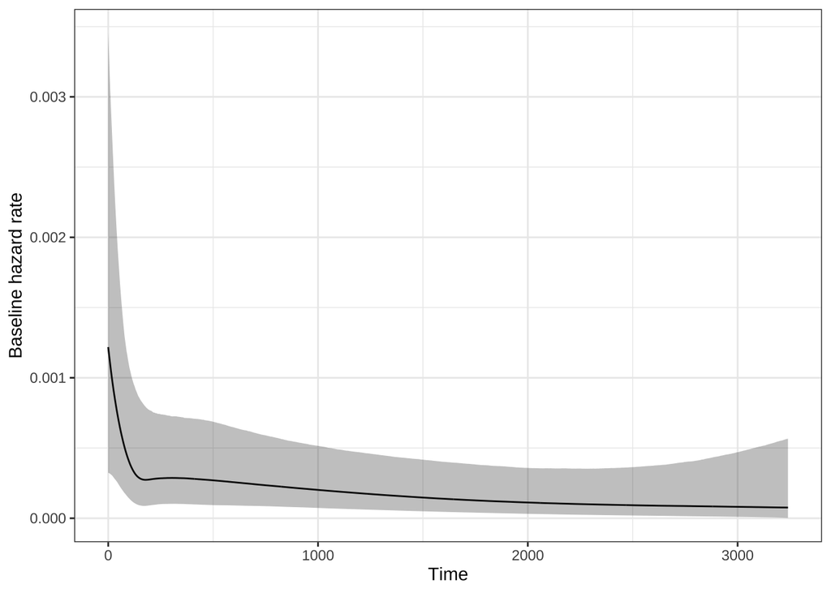

```r
plot(mod_type)
```

## Plots of model convergences

## Get results

```r
posterior_mod_type <- as.array(mod_type)
```

### a. Check trace plots for model

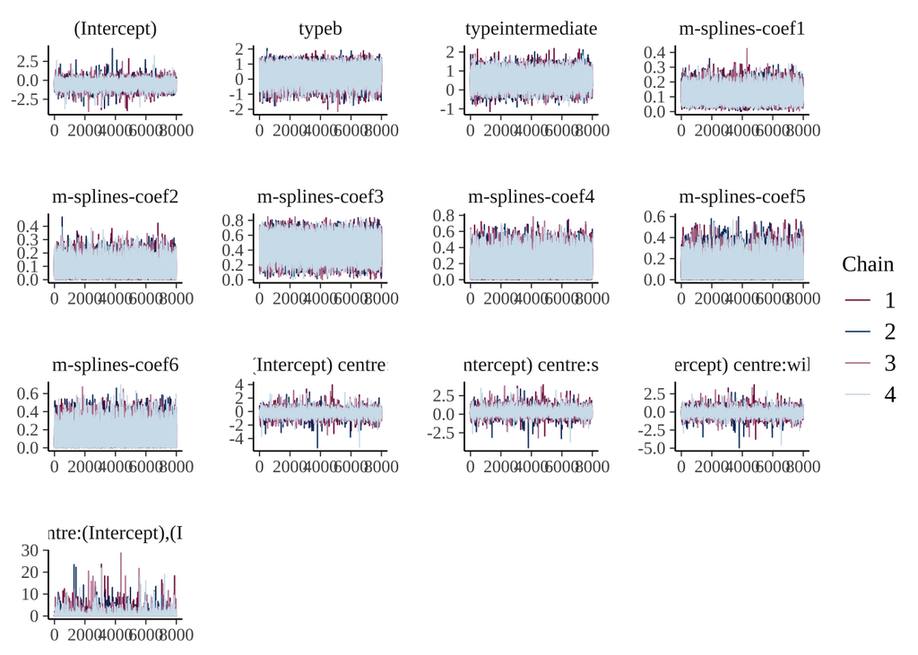

```r
color_scheme_set("mix-blue-pink")
mcmc_trace(posterior_mod_type)
```

### b. Trace rank plot

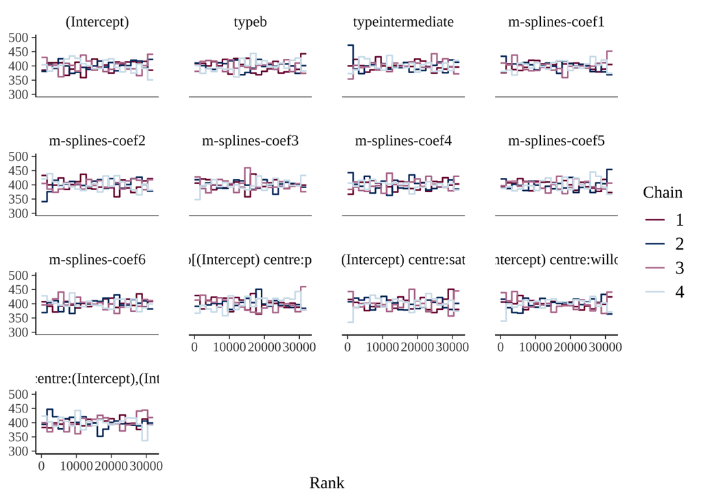

```r
color_scheme_set("mix-blue-pink")
mcmc_rank_overlay(posterior_mod_type) +
  ylim(300, 500)
```

### c. get dens overlay plot for chains

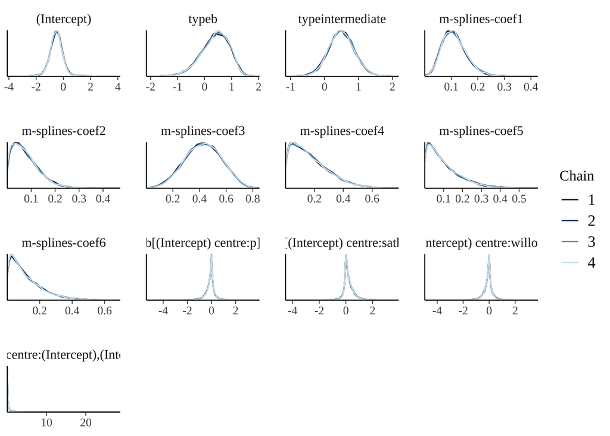

```r
color_scheme_set("blue")
mcmc_dens_overlay(posterior_mod_type)
```

## Summaries of coefficients

### a. HPDI for the different beta parameters

```r
draws <- as.matrix(mod_type)
median(draws[,3]) # draws for type
```

```
## [1] 0.4965462
```

```r
HPDI(draws[,3], 0.97) # draws for type_intermediate
```

```
##     |0.97     0.97|
## -0.321436  1.327273
```

```r
HPDI(draws[,3], 0.89) # draws for type_intermediate
```

```
##       |0.89       0.89|
## -0.09290241  1.10965594
```

#### type_b

```r
draws <- as.matrix(mod_type)
median(draws[,2]) # draws for type_b
```

```
## [1] 0.4332402
```

```r
HPDI(draws[,2], 0.97) # draws for type_b
```

```
##      |0.97      0.97|
## -0.7636334  1.3735748
```

```r
HPDI(draws[,2], 0.89) # draws for type_b
```

```
##      |0.89      0.89|
## -0.3975374  1.1975222
```

### b. Hypothesis tests on beta parameters

#### type_intermediate

probability that effect is positive

```r
mean(draws[,3] > 0) #  draws for type_intermediate
```

```
## [1] 0.9110312
```

#### type_b

probability that effect is positive

```r
mean(draws[,2] > 0) # draws for type_b
```

```
## [1] 0.7798437
```

```r
type_intermediate <- draws[,3] # draws for type_intermediate)
type_b <- draws[,2] # draws for type_b)
```

### c. Plot posterior distribution for beta coefficient

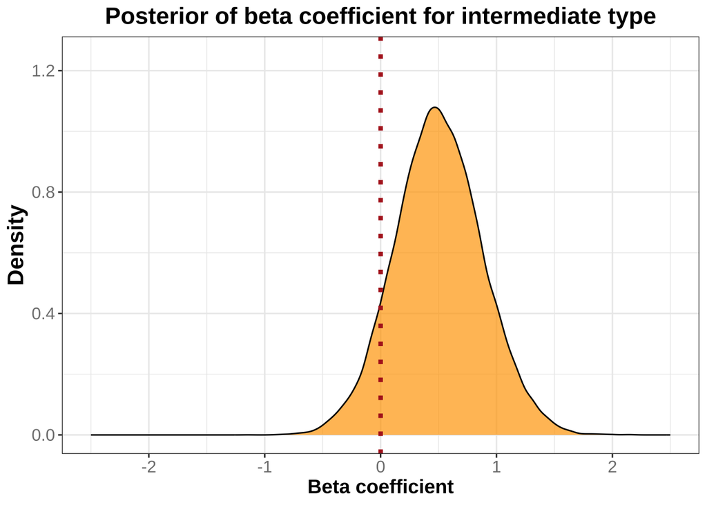

```r
ggplot(data.frame(type_intermediate), aes(x = type_intermediate)) +
  geom_density(fill = "orange", alpha = 0.7) +
  labs(title = "Posterior of beta coefficient for intermediate type",
       x = "Beta coefficient",
       y = "Density") +
  theme_bw() +
           theme(axis.title.y = element_text(size=16, face="bold"),
               axis.title.x = element_text(size=14, face="bold"),
               title = element_text(size=14, face="bold"),
               plot.title = element_text(hjust = 0.5),
               axis.text.x = element_text(color = "grey50", size = 12),
               axis.text.y = element_text(color = "grey50",size = 12)) +
  geom_vline(xintercept = 0, linetype="dotted",
                color = "firebrick", linewidth = 1.5) +
  xlim(-2.5, 2.5) +
  ylim(0, 1.25)
```

#### ii. type_b

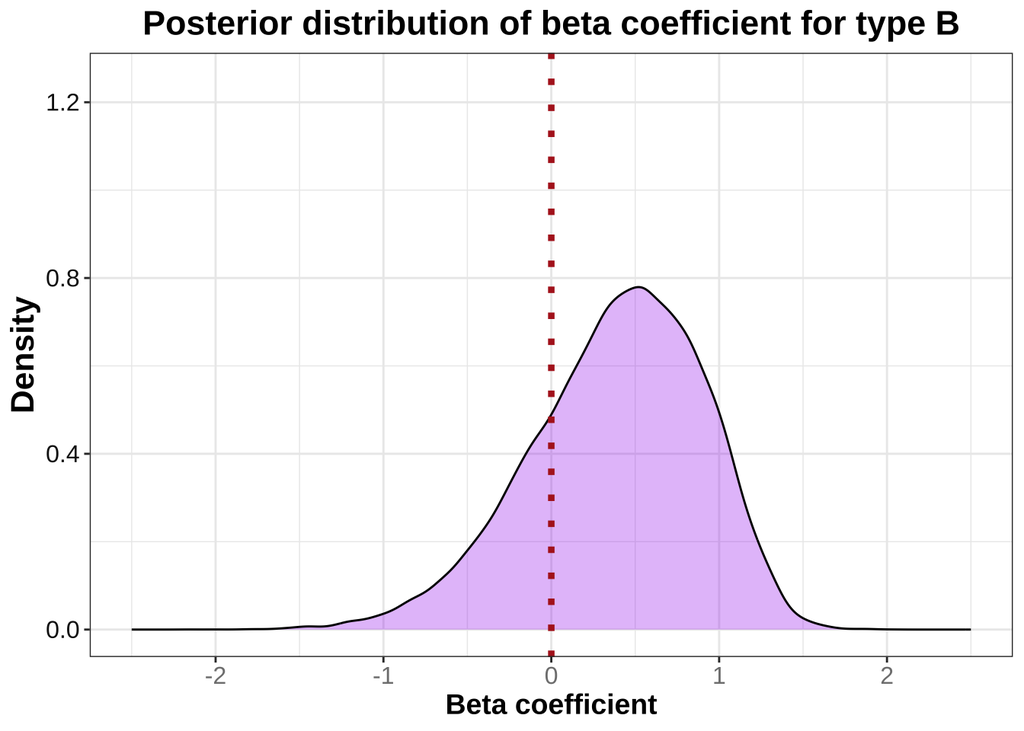

```r
ggplot(data.frame(type_b), aes(x = type_b)) +
  geom_density(fill = "purple", alpha = 0.3) +
  labs(title = "Posterior distribution of beta coefficient for type B",
       x = "Beta coefficient",
       y = "Density") +
  theme_bw() +
           theme(axis.title.y = element_text(size=16, face="bold"),
               axis.title.x = element_text(size=14, face="bold"),
               title = element_text(size=14, face="bold"),
               plot.title = element_text(hjust = 0.5),
               axis.text.x = element_text(color = "grey50", size = 12),
               axis.text.y = element_text(color = "grey8",size = 12)) +
  geom_vline(xintercept = 0, linetype="dotted",
                color = "firebrick", linewidth = 1.5) +
  xlim(-2.5, 2.5) +
  ylim(0, 1.25)
```

## Get HDI for coefficients

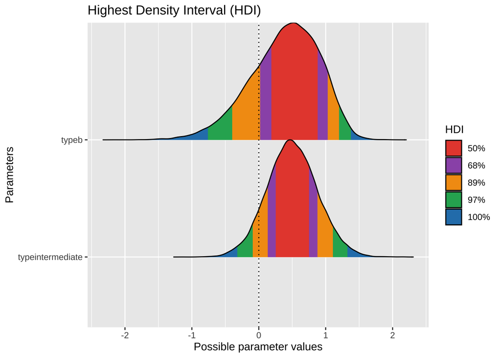

```r
hdi <- bayestestR::hdi(mod_type, ci = c(0.50, 0.68, 0.89, 0.97), parameters = "type")
plot(hdi)
```

## Get density plots for posterior distributons of beta parameters

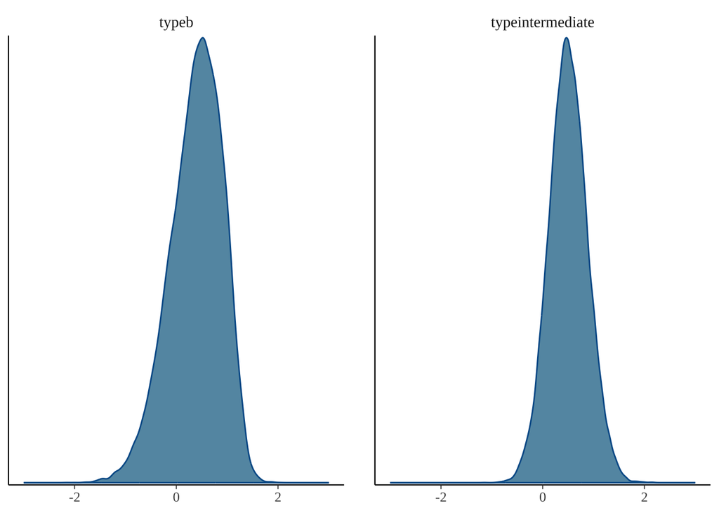

```r
mcmc_dens(posterior_mod_type,
  pars = c("typeb", "typeintermediate")) +
  xlim(-3,3)
```

## Get area plot for posterior distributons of beta parameters

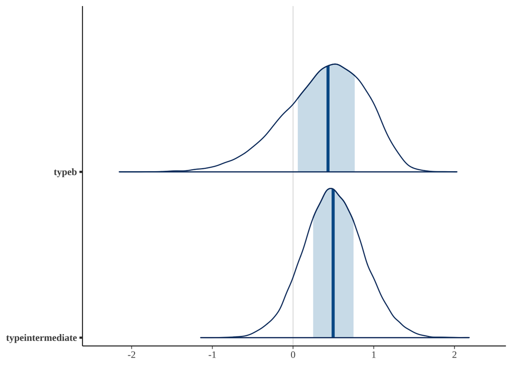

```r
mcmc_areas(posterior_mod_type,
  pars = "typeb", "typeintermediate")
```

## Calculate hazard ratios for type

### a. get posterior draws

```r
type_intermediate_hr <- exp(draws[,3]) # draws for type_intermediate)
type_b_hr <- exp(draws[,2]) # draws for type_b)
```

### b. Summarise hazard ratios

#### i. type_intermediate

```r
median(type_intermediate_hr)
```

```
## [1] 1.643037
```

```r
hpdi_type_intermediate_hr <- HPDI(type_intermediate_hr, prob = c(0.89, 0.97))
hpdi_type_intermediate_hr
```

```
##     |0.97     |0.89     0.89|     0.97|
## 0.5961250 0.7827434 2.7642001 3.4596560
```

#### ii. type_b

```r
median(type_b_hr)
```

```
## [1] 1.542247
```

```r
hpdi_type_b_hr <- HPDI(type_b_hr, prob = c(0.89, 0.97))
hpdi_type_b_hr
```

```
##     |0.97     |0.89     0.89|     0.97|
## 0.2913014 0.4351968 2.7877460 3.4258462
```

### c. Plot posterior distribution for hazard ratio

#### i. type_intermediate

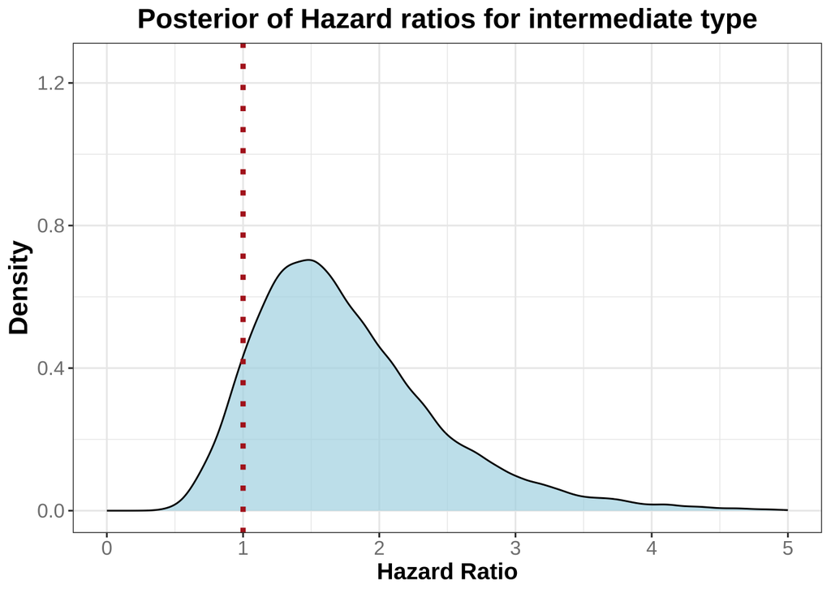

```r
ggplot(data.frame(type_intermediate_hr), aes(x = type_intermediate_hr)) +
  geom_density(fill = "lightblue", alpha = 0.7) +
  labs(title = "Posterior of Hazard ratios for intermediate type",
       x = "Hazard Ratio",
       y = "Density") +
  theme_bw() +
           theme(axis.title.y = element_text(size=16, face="bold"),
               axis.title.x = element_text(size=14, face="bold"),
               title = element_text(size=14, face="bold"),
               plot.title = element_text(hjust = 0.5),
               axis.text.x = element_text(color = "grey50", size = 12),
               axis.text.y = element_text(color = "grey50",size = 12)) +
  geom_vline(xintercept = 1, linetype="dotted",
                color = "firebrick", linewidth = 1.5) +
  xlim(0, 5) +
  ylim(0, 1.25)
```

#### ii. type_b

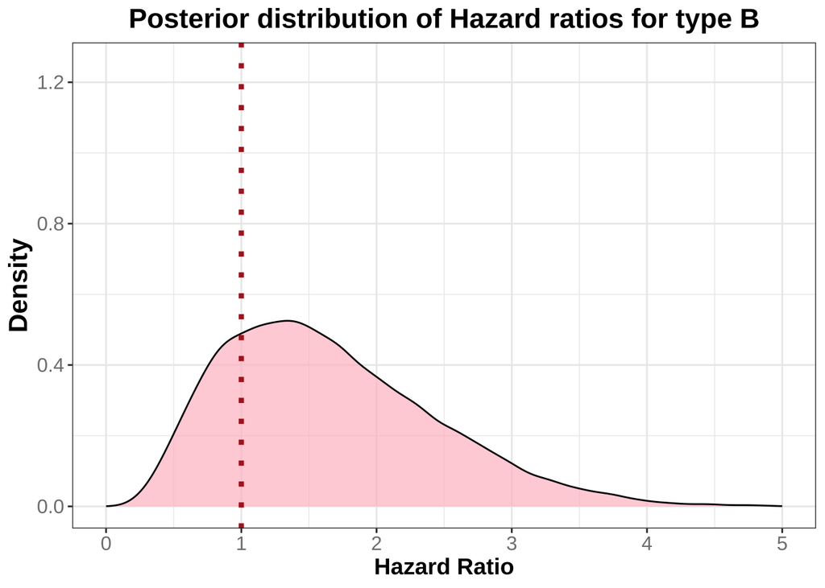

```r
ggplot(data.frame(type_b_hr), aes(x = type_b_hr)) +
  geom_density(fill = "pink", alpha = 0.7) +
  labs(title = "Posterior distribution of Hazard ratios for type B",
       x = "Hazard Ratio",
       y = "Density") +
  theme_bw() +
           theme(axis.title.y = element_text(size=16, face="bold"),
               axis.title.x = element_text(size=14, face="bold"),
               title = element_text(size=14, face="bold"),
               plot.title = element_text(hjust = 0.5),
               axis.text.x = element_text(color = "grey50", size = 12),
               axis.text.y = element_text(color = "grey50",size = 12)) +
  geom_vline(xintercept = 1, linetype="dotted",
                color = "firebrick", linewidth = 1.5) +
  xlim(0, 5) +
  ylim(0, 1.25)
```

## Check model performance

### 1. Check performance of posterior probability

NB equivalent of pp_check

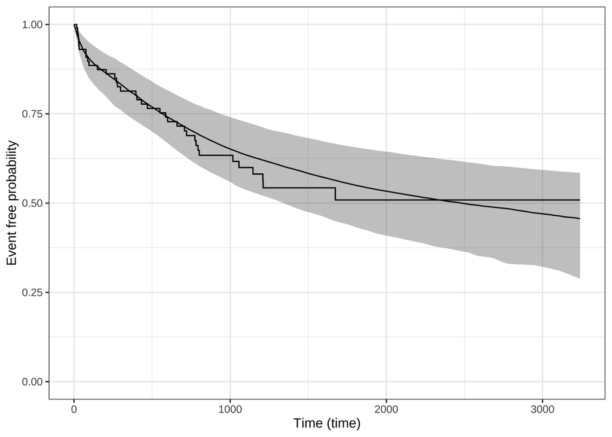

```r
ps_check(mod_type) |>
  suppressWarnings()
```

### 2. Check performance of prior probability

```r
mod_type_prior_only <- update(mod_type, prior_PD = TRUE)
```

[output not shown]

[output not shown]

[output not shown]

[output not shown]

[output not shown]

[output not shown]

[output not shown]

[output not shown]

[output not shown]

[output not shown]

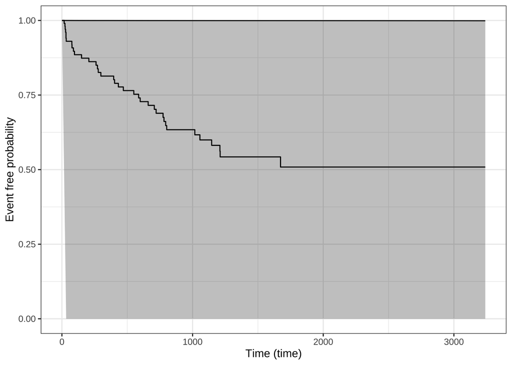

```r
ps_check(mod_type_prior_only) |>
  suppressWarnings()
```

### 3. Check prosterior vs prior for beta variable

#### a. extract draws for posterior and prior

```r
# extract draws
post_draws  <- as.matrix(mod_type)
prior_draws <- as.matrix(mod_type_prior_only)
```

#### b. type_intermediate

##### i. plot marginal distributions for posterior and prior

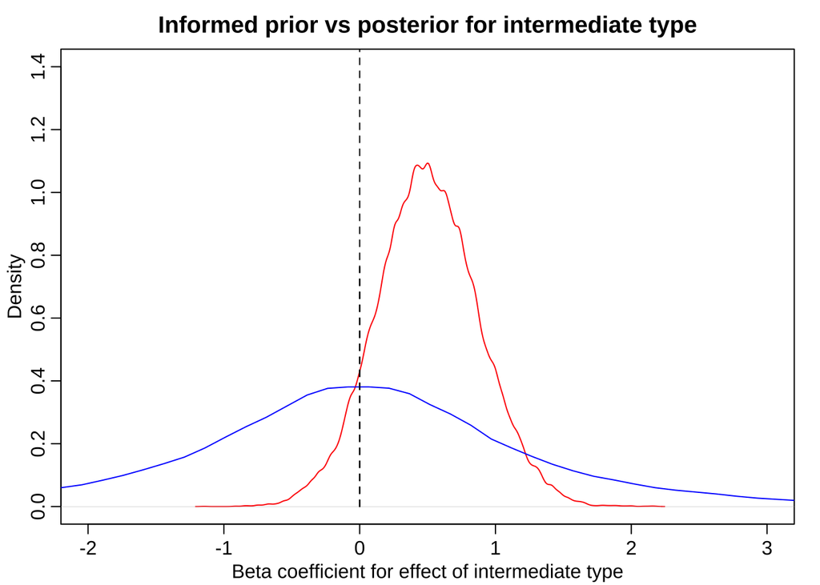

```r
# Compare marginal distributions
dens(post_draws[, "typeintermediate"], show.zero = TRUE, col = "red", main = "Informed prior vs posterior for intermediate type", xlab = "Beta coefficient for effect of intermediate type", xlim = c(-2, 3), ylim = c(0, 1.4) )
dens(prior_draws[, "typeintermediate"], add=TRUE, col = "blue", show.zero = TRUE)
```

##### ii. compute prior tail probability of posterior mean

If this probability is very small (e.g. < 0.05), the posterior lies in a region the prior considered implausible.

```r
beta_hat <- mean(post_draws[, "typeintermediate"])

mean(abs(prior_draws[, "typeintermediate"] - beta_hat) <
       abs(prior_draws[, "typeintermediate"] - mean(prior_draws[, "typeintermediate"])))
```

```
## [1] 0.4096875
```

#### b. type_b

##### i. plot marginal distributions for posterior and prior

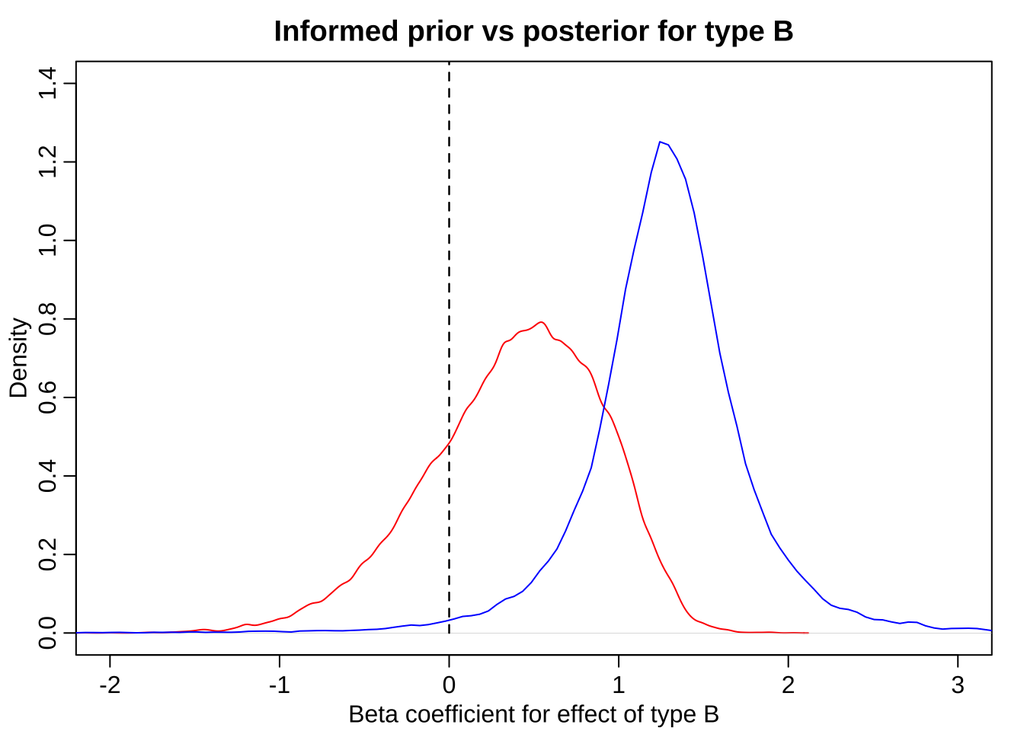

```r
# Compare marginal distributions
dens(post_draws[, "typeb"], show.zero = TRUE, col = "red", main = "Informed prior vs posterior for type B",
     xlab = "Beta coefficient for effect of type B", xlim = c(-2, 3), ylim = c(0, 1.4) )
dens(prior_draws[, "typeb"], add=TRUE, col = "blue", show.zero = TRUE)
```

##### ii. compute prior tail probability of posterior mean

If this probability is very small (e.g. < 0.05), the posterior lies in a region the prior considered implausible.

```r
beta_hat <- mean(post_draws[, "typeb"])

mean(abs(prior_draws[, "typeb"] - beta_hat) <
       abs(prior_draws[, "typeb"] - mean(prior_draws[, "typeb"])))
```

```
## [1] 0.1255938
```

### 4. Sensitivity analyses to assess robustness of results to choice of prior

#### a. create priors of different strength for type variable

To determine whether the substantive conclusions depend upon the exact prior choice. Given such a small scale, best to adjust the strong prior is based on the combined estimate from the literature, whilst moderate and weak priors are then scaled up from the strong prior. These latter priors ensure that the data are not overwhelmed by the prior, but still allow for some regularisation to improve model convergence and reduce overfitting. Therefore, strong prior should be 1x the combine scale, then increase this by 2x for moderate and 4x for weak..

```r
priors_bin <- list(
  weak = student_t(df = 3, location = c(1.292032, 0), scale = c(1.2877111, 2.0), autoscale = FALSE),
  moderate = student_t(df = 3, location = c(1.292032, 0), scale = c(0.6438556, 1.0), autoscale = FALSE),
  strong = student_t(df = 3, location = c(1.292032, 0), scale = c(0.3219278, 0.5), autoscale = FALSE)
)
```

**Set an informative, weakly-regularising prior…**

student_t(df = 3, location = 1.29611, scale = 0.3244759)

```
  suggested scale
```

strong 0.3219278 moderate 0.6438556 weak 1.2877111

#### b. refit model with different priors and compare results

```r
fits <- lapply(priors_bin, function(p) {
  stan_surv(formula = Surv(time, status) ~ type
            + (1| centre),
            basehaz = "ms",
            data = df,
            prior_intercept = normal(location = 0, scale = 5, autoscale = FALSE),
            prior = p,
            prior_covariance =  decov(regularization = 2, concentration = 1, shape = 1, scale = 1),
            iter    = 2000,
            chains = 4,
            cores = 4,
            adapt_delta = 0.9999,  # Often helpful for complex models
            seed = 666
            )
})
```

[output not shown]

[output not shown]

[output not shown]

[output not shown]

[output not shown]

[output not shown]

[output not shown]

[output not shown]

[output not shown]

[output not shown]

[output not shown]

[output not shown]

[output not shown]

[output not shown]

[output not shown]

[output not shown]

[output not shown]

[output not shown]

[output not shown]

[output not shown]

[output not shown]

[output not shown]

[output not shown]

[output not shown]

[output not shown]

[output not shown]

#### c. compare posterior intervals for hazard ratios for type_intermediate across different priors

##### i. type_intermediate

```r
# calculate median hazard ratio for type_intermediate across different priors
HR_med_sens <- sapply(fits, function(f) {
  posterior::as_draws_df(f) |>
    as.data.frame() |>
    summarise(
      median = exp(quantile(typeintermediate, probs = 0.5))
    )
})
HR_med <- c(HR_med_sens[[1]], HR_med_sens[[2]], HR_med_sens[[3]])


# calculate 89% credible interval for hazard ratio for type_intermediate across different priors
HR_sens <- sapply(fits, function(f) {
  exp(posterior_interval(f, pars = "typeintermediate", prob = 0.89))
})

# combine median and credible intervals into a summary table
HR_sens_summary <- rbind(HR_med, HR_sens)
row.names(HR_sens_summary) <- c("Median", "Lower", "Upper")

# transpose the table for better readability
HR_sens_summary
```

```
##             weak  moderate    strong
## Median 1.4346585 1.4877731 1.4321126
## Lower  0.7867806 0.8665223 0.8723783
## Upper  2.6606217 2.6096596 2.5181733
```

##### ii. type_b

```r
# calculate median hazard ratio for type_b across different priors
HR_med_sens <- sapply(fits, function(f) {
  posterior::as_draws_df(f) |>
    as.data.frame() |>
    summarise(
      median = exp(quantile(typeb, probs = 0.5))
    )
})
HR_med <- c(HR_med_sens[[1]], HR_med_sens[[2]], HR_med_sens[[3]])


# calculate 89% credible interval for hazard ratio for type_b across different priors
HR_sens <- sapply(fits, function(f) {
  exp(posterior_interval(f, pars = "typeb", prob = 0.89))
})

# combine median and credible intervals into a summary table
HR_sens_summary <- rbind(HR_med, HR_sens)
row.names(HR_sens_summary) <- c("Median", "Lower", "Upper")

# transpose the table for better readability
HR_sens_summary
```

```
##             weak  moderate    strong
## Median 0.8900243 1.1428685 1.3946540
## Lower  0.3641705 0.4674654 0.5816653
## Upper  1.9705592 2.3245111 2.8413753
```

## Make model predictions and plot

### 1. Create new data where type differs

```r
nd1 <- data.frame(type = c("a", "b", "intermediate"),
                 centre = c("p", "p", "p"))
head(nd1)
```

```
##           type centre
## 1            a      p
## 2            b      p
## 3 intermediate      p
```

### 2. Make posterior predictions from new data

```r
ps <- posterior_survfit(mod_type,
  newdata = nd1,
  times = 0,
  extrapolate = TRUE) |>
  suppressWarnings()
head(ps)
```

```
## stan_surv predictions
##  num. individuals: 3
##  prediction type:  event free probability
##  standardised?:    no
##  conditional?:     no
##
##   id cond_time     time median  ci_lb  ci_ub
## 1  1        NA   0.0000 1.0000 1.0000 1.0000
## 2  1        NA  32.7273 0.9701 0.9280 0.9916
## 3  1        NA  65.4545 0.9501 0.8866 0.9852
## 4  1        NA  98.1818 0.9355 0.8620 0.9800
## 5  1        NA 130.9091 0.9247 0.8437 0.9758
## 6  1        NA 163.6364 0.9156 0.8246 0.9710
```

#### 3. Plot

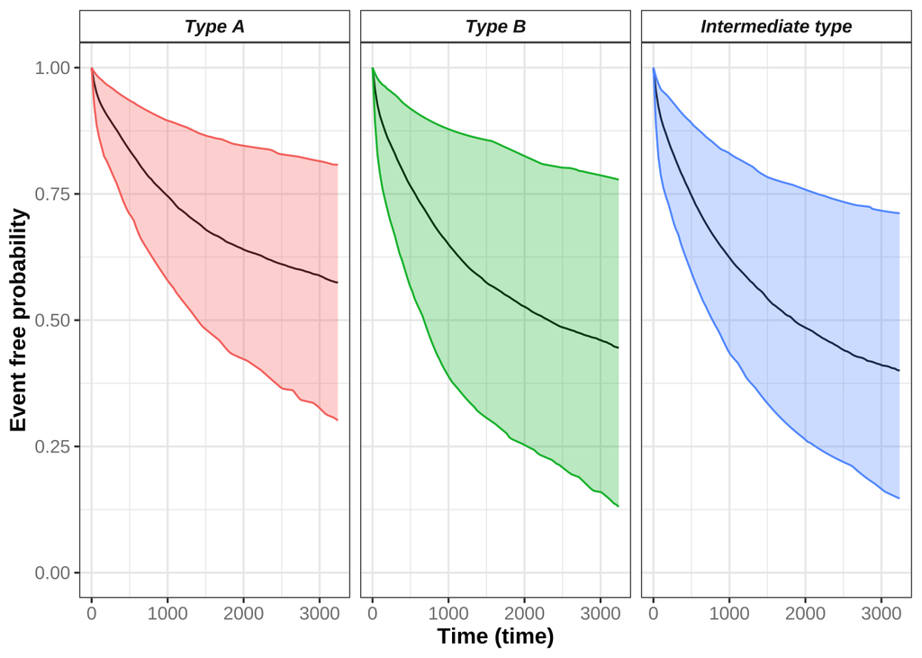

```r
panel_labels <- c('1' = "Type A", '2' = "Type B", '3' = "Intermediate type")
pps <- plot(ps) +
  aes(colour = factor(id), fill = factor(id)) +
  theme(legend.position = "none") +
  facet_wrap(~ id, labeller = labeller(id = panel_labels)) +
           theme(axis.title.y = element_text(size=12, face="bold"),
               axis.title.x = element_text(size=12, face="bold"),
               title = element_text(size=12, face="bold"),
               plot.title = element_text(hjust = 0.5),
               axis.text.x = element_text(color = "grey50", size = 10),
               axis.text.y = element_text(color = "grey50",size = 10)) +
            theme(strip.text.x = element_text(size = 10, face = "bold.italic"),
                   strip.background = element_rect(fill="white")
        )
print(pps)
```

## Check PH assumption visually

### make predictions of both the hazard and log hazard

```r
ph <- suppressWarnings( posterior_survfit(mod_type, newdata = nd1, type = "haz") )
pl <- suppressWarnings( posterior_survfit(mod_type, newdata = nd1, type = "loghaz") )
```

#### create plots

```r
pph <- plot(ph) +
  facet_wrap(~ id, labeller = labeller(id = panel_labels))
ppl <- plot(pl) +
  facet_wrap(~ id, labeller = labeller(id = panel_labels))
```

#### combine plots in grid and plot

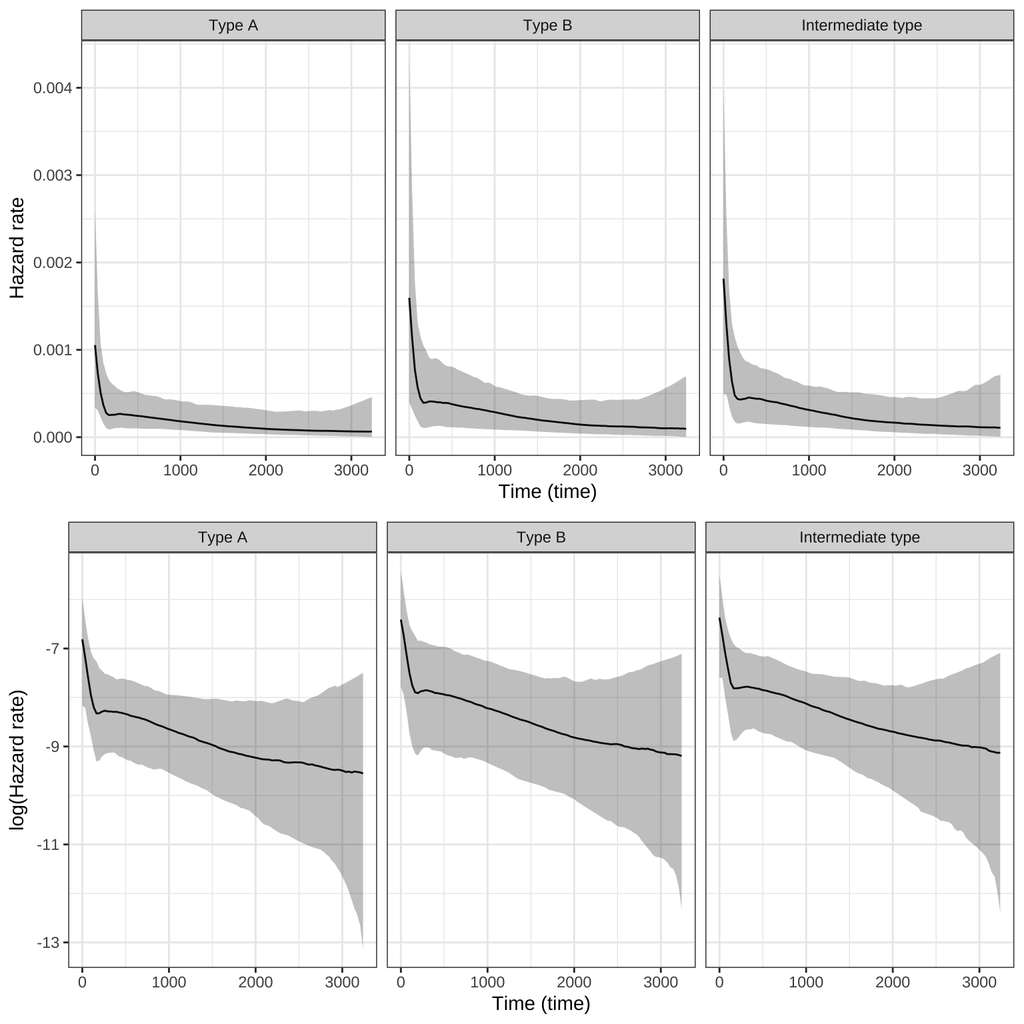

```r
plot_grid(pph, ppl, ncol = 1)
```

# II. Bayesian multi-level survival analysis for s_age with random intercept for centre

## Set prior for beta variables

**Set an informative prior…**

student_t(df = 3, location = 0.1731489, scale = 0.1596095)

```r
prior_beta_age <- student_t(df = 3, location = 0.1731489, scale = 0.1596095, autoscale = FALSE)
```

## Fit model with for s_age

NB use status … rstanarm requires the dead animals to be classified as 1, whilst censored are 0.

```r
mod_age <- stan_surv(formula = Surv(time, status) ~ s_age
                     + (1| centre),
  data = df,
  basehaz = "ms",
  prior_intercept = normal(location = 0, scale = 22.5, autoscale = FALSE),
  prior = prior_beta_age,
  prior_covariance =  decov(regularization = 2, concentration = 1, shape = 1, scale = 1),
  iter    = 12000,
  warmup = 4000,
  chains = 4,
  cores = 4,
  adapt_delta = 0.99999,  # Often helpful for complex models
  seed = 666)
```

[output not shown]

[output not shown]

[output not shown]

[output not shown]

[output not shown]

[output not shown]

[output not shown]

[output not shown]

[output not shown]

[output not shown]

## Summarise priors from model

```r
prior_summary(mod_age)
```

```
## Priors for model 'mod_age'
## ------
## Intercept
##  ~ normal(location = 0, scale = 22)
##
## Coefficients
##  ~ student_t(df = 3, location = 0.17, scale = 0.16)
##
## Auxiliary (M-spline-coefficients)
##  ~ dirichlet(concentration = [1,1,1,...])
##
## Covariance
##  ~ decov(reg. = 2, conc. = 1, shape = 1, scale = 1)
## ------
## See help('prior_summary.stanreg') for more details
```

## Model summary

```r
summary(mod_age)
```

```
##
## Model Info:
##
##  function:        stan_surv
##  baseline hazard: M-splines on hazard scale
##  formula:         Surv(time, status) ~ s_age + (1 | centre)
##  algorithm:       sampling
##  sample:          32000 (posterior sample size)
##  priors:          see help('prior_summary')
##  observations:    112
##  events:          36 (32.1%)
##  right censored:  76 (67.9%)
##  delayed entry:   no
##
## Estimates:
##                                         mean   sd   10%   50%   90%
## (Intercept)                           -0.2    0.5 -0.8  -0.2   0.3
## s_age                                  0.2    0.1  0.0   0.2   0.3
## m-splines-coef1                        0.1    0.0  0.1   0.1   0.2
## m-splines-coef2                        0.1    0.1  0.0   0.1   0.2
## m-splines-coef3                        0.4    0.1  0.2   0.4   0.6
## m-splines-coef4                        0.2    0.1  0.0   0.2   0.4
## m-splines-coef5                        0.1    0.1  0.0   0.1   0.2
## m-splines-coef6                        0.1    0.1  0.0   0.1   0.3
## b[(Intercept) centre:p]               -0.3    0.5 -0.8  -0.2   0.2
## b[(Intercept) centre:sath]             0.3    0.5 -0.1   0.2   0.9
## b[(Intercept) centre:willows]          0.0    0.5 -0.5   0.0   0.4
## Sigma[centre:(Intercept),(Intercept)]  0.6    1.3  0.0   0.2   1.3
##
## MCMC diagnostics
##                                       mcse Rhat n_eff
## (Intercept)                           0.0  1.0   9517
## s_age                                 0.0  1.0  23401
## m-splines-coef1                       0.0  1.0  37117
## m-splines-coef2                       0.0  1.0  20048
## m-splines-coef3                       0.0  1.0  23631
## m-splines-coef4                       0.0  1.0  21889
## m-splines-coef5                       0.0  1.0  34874
## m-splines-coef6                       0.0  1.0  32769
## b[(Intercept) centre:p]               0.0  1.0  10786
## b[(Intercept) centre:sath]            0.0  1.0   9158
## b[(Intercept) centre:willows]         0.0  1.0   9408
## Sigma[centre:(Intercept),(Intercept)] 0.0  1.0  11463
## log-posterior                         0.0  1.0   8323
##
## For each parameter, mcse is Monte Carlo standard error, n_eff is a crude measure of effective sample size, and Rhat is the potential scale reduction factor on split chains (at convergence Rhat=1).
```

## Model short summary… shows estimates of coefficients

```r
print(mod_age, digits = 3)
```

```
## stan_surv
##  baseline hazard: M-splines on hazard scale
##  formula:         Surv(time, status) ~ s_age + (1 | centre)
##  observations:    112
##  events:          36 (32.1%)
##  right censored:  76 (67.9%)
##  delayed entry:   no
## ------
##                 Median MAD_SD exp(Median)
## (Intercept)     -0.220  0.363     NA
## s_age            0.159  0.109  1.172
## m-splines-coef1  0.101  0.045     NA
## m-splines-coef2  0.076  0.059     NA
## m-splines-coef3  0.402  0.149     NA
## m-splines-coef4  0.162  0.139     NA
## m-splines-coef5  0.081  0.081     NA
## m-splines-coef6  0.087  0.085     NA
##
## Error terms:
##  Groups Name        Std.Dev.
##  centre (Intercept) 0.749
## Num. levels: centre 3
##
## ------
## * For help interpreting the printed output see ?print.stanreg
## * For info on the priors used see ?prior_summary.stanreg
```

## Plot Baseline hazard of model

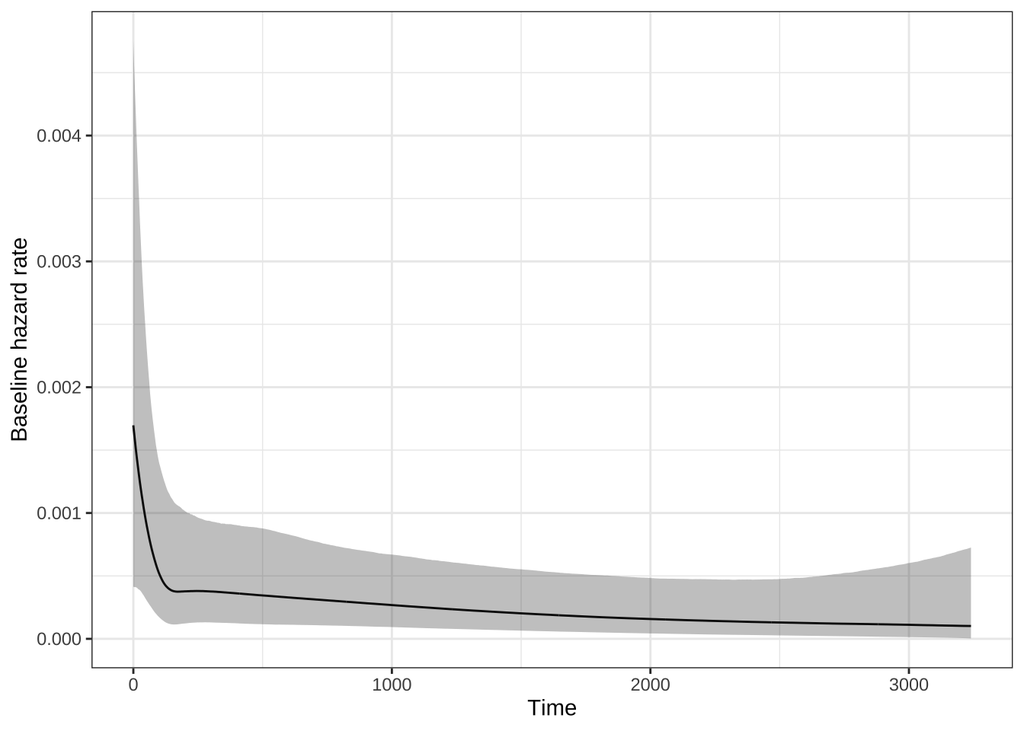

```r
plot(mod_age)
```

## Plots of model convergences

## Get results

```r
posterior_mod_age <- as.array(mod_age)
```

### a. Check trace plots for model

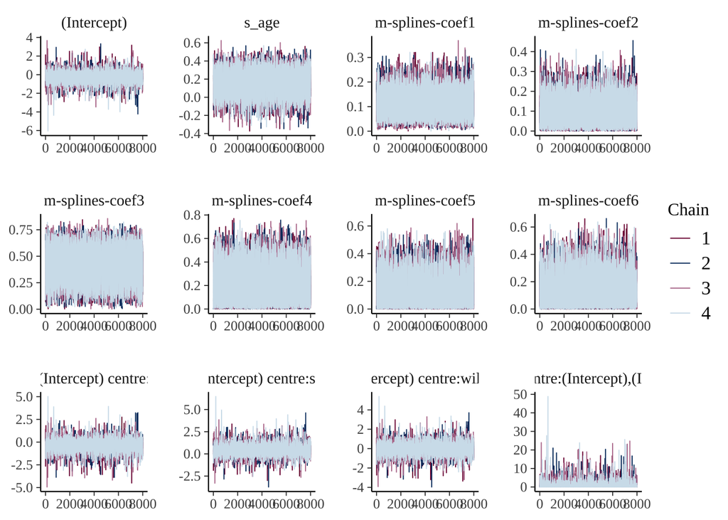

```r
color_scheme_set("mix-blue-pink")
mcmc_trace(posterior_mod_age)
```

### b. Trace rank plot

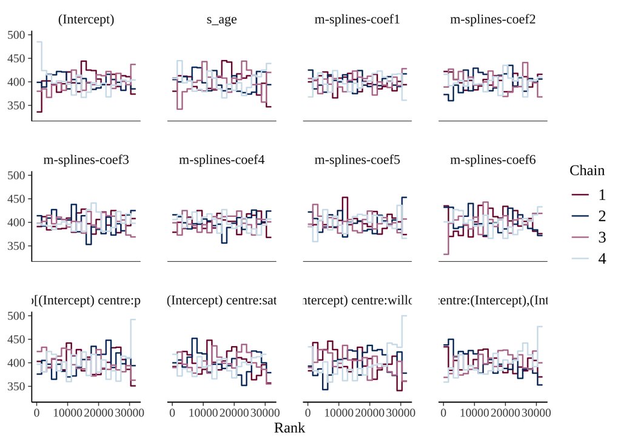

```r
color_scheme_set("mix-blue-pink")
mcmc_rank_overlay(posterior_mod_age)  +
  ylim(325, 500)
```

### c. get dens overlay plot for chains

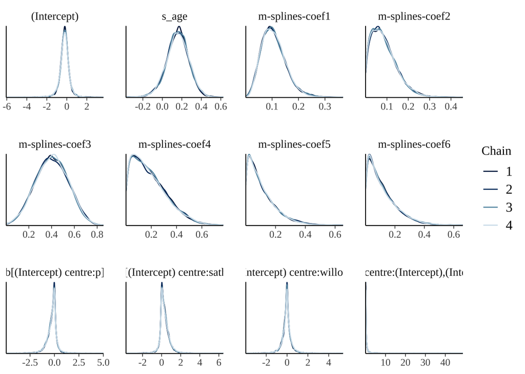

```r
color_scheme_set("blue")
mcmc_dens_overlay(posterior_mod_age)
```